# Visión Artificial

## Práctica 1: Ecualización global (GHE) vs Ecualización adaptativa (CLAHE) y espacios de color 🎨

### Datos

|  | Detalle |
| --- | --- |
| **📚 Materia** | Visión Artificial |
| **🎓 Programa** | Maestría en Ciencia de Datos |
| **📅 Periodo** | 3° Semestre (Agosto-Diciembre 2026) |
| **👨‍💻 Autor** | Abraham Eduardo Ordorica Islas |
| **🏷️ Perfil Asignado** | Perfil 2 |
| **📝 Fecha** | 17 de Agosto de 2026 |

## 1. Marco teórico

### 1.1 Espacios de Color y Desacoplamiento de Cromaticidad

En procesamiento de imágenes, un espacio de color es un modelo matemático abstracto que permite representar los colores mediante arreglos de números, bajo un estándar de interpretación acordado. Matemáticamente, los espacios de color se pueden definir como espacios N-dimensionales, en los cuales, una coordenada representa un color específico. Existen espacios Acoplados como el **RGB** y desacoplados como el **LAB,HSV,YCbCr** entre otros.

- Un espacio de color **RGB**, se puede definir como un cubo en el que cada una de sus aristas representa un componente Rojo (R), Verde(G) y Azul(B). La combinación de sus valores individuales (0-255) genera una combinación de color (**cromaticidad**) y brillo (**luminancia**) única dentro de todo el espacio.

[figure not shown]

- Un espacio de color **Lab** puede representarse como una esfera, en el cual el eje **L representa la luminancia**, **+-a** representa el espectro de color **entre el verde y el rojo** y **+-b** representa el espectro de **color entre el amarillo y el azul**. Este espacio de color es desacoplado, pues **las coredenadas de la luminancia se encuentran separadas de la cromaticidad**

[figure not shown]

- Un espacio de color **hsv** se representa como un cilindro, en el cual **la cromaticidad se representa por los grados del Matiz (Hue) y la distancia al eje central llamada saturación (S)**. **La altura del cilindro representa la Luminancia por medio del valor (V)**. Este también es un espacio de color desacoplado y es el que más se asemeja a la forma en la que los humanos perciben el color.

[figure not shown]

| Espacio de Color | Canal de Brillo / Luminancia | Canales Cromáticos (Color) | Uso Típico |
| --- | --- | --- | --- |
| **RGB** | Acoplado en $R, G, B$ | Acoplados | Sensores de captura, pantallas |
| **LAB** | $L^*$ (Luminosidad: $0 \leftrightarrow 100$) | $a^*$ (Verde $\leftrightarrow$ Rojo) $b^*$ (Azul $\leftrightarrow$ Amarillo) | Evaluación perceptual uniforme, medicina |
| **HSV** | $V$ (Valor/Brillo: $0 \leftrightarrow 255$) | $H$ (Tinte: $0 \leftrightarrow 179$) $S$ (Saturación: $0 \leftrightarrow 255$) | Segmentación basada en percepción humana |

### 1.2 Ecualización de Histograma: Global vs. CLAHE

Ecualizar una imagen significa mejorar de forma automática su contraste. Es un proceso que redistribuye los tonos de la imagen para que las zonas oscuras y claras se aprovechen al máximo. el proceso se divide en 3 pasos bien definidos:

1. Examina la gráfica que muestra cuántos píxeles oscuros, medios y claros tiene la imagen.
2. Identifica la "calidad" de la imagen, pixeles concentrados en los grises, en los tonos claros u oscuros.
3. Distribuye los píxeles de manera uniforme a lo largo de toda la escala (de negro puro a blanco puro).

Es una técnica ampliamente utilizada para encontrar información escondida en los negros profundos o blancos quemados de imágenes médicas, imágenes geográficas satelitales u optimizar el resultado de sistemas de visión artificial

[figure not shown]

- **Ecualización Global:** Redistribuye la densidad de probabilidad de los niveles de intensidad de toda la imagen de forma uniforme mediante la función de distribución acumulada (CDF).
  - *Limitación:* Tiende a sobreexponer regiones ya claras, oscurecer zonas tenues y amplificar drásticamente el ruido de fondo en imágenes con iluminación heterogénea.
- **CLAHE (*Contrast Limited Adaptive Histogram Equalization*):** Divide la imagen en bloques contextuales o teselas (*tiles*), ecualiza localmente sobre cada "subimagen", permitiendo realzar contrastes sobre zonas "problemáticas" y evitando disparar el ruido sobre zonas altamente contrastadas originalmente.
  - **`clipLimit`:** Umbral que limita la amplificación de contraste. El exceso del histograma por encima de este valor se redistribuye uniformemente entre todos los niveles antes de la CDF, previniendo la amplificación del ruido.
  - **`tileGridSize`:** Tamaño de la cuadrícula ($N \times M$, típicamente $8 \times 8$). Determina la escala espacial del vecindario local evaluado.

> ⚠️ **¿Por qué NO ecualizar directamente en RGB?**  
> Debido a que el espacio de color RGB es un espacio **acoplado**, si se aplica ecualización de histograma de forma independiente sobre los canales $R$, $G$ y $B$, se rompen las proporciones relativas de los colores, provocando **virados cromáticos indeseados** (*color shift*) y ruido excesivo. Al transformar a un espacio desacoplado (como **CIELAB** o **HSV**), se opera **únicamente sobre el canal de luminosidad ($L^*$)**, garantizando que el tono y la pureza del color original permanezcan intactos.

### 1.3 Contraste RMS (*Root Mean Square Contrast*)

El contraste **RMS** (Root Mean Square o Raíz Cuadrática Media) es una métrica estadística que **mide el contraste global de una imagen basándose en la desviación estándar** de las intensidades de sus píxeles.A diferencia del contraste simple (que solo mira la diferencia entre el píxel más claro y el más oscuro), **el contraste RMS analiza todos los píxeles para determinar qué tan dispersos están los tonos respecto al brillo promedio**.

$$C_{RMS} = \sqrt{\frac{1}{M \cdot N} \sum_{i=0}^{M-1} \sum_{j=0}^{N-1} \left( I(i,j) - \bar{I} \right)^2}$$

Donde:

- $I(i,j)$ ntensidad del píxel en la posición $(i, j)$ (Normalizada entre $[0, 1]$).
- $\bar{I}$ es la intensidad promedio de todos los pixeles.
- $M, N$ son las dimensiones de la imagen. ${M \cdot N}$ Es el número total de pixeles en la imagen.

Un incremento en $C_{RMS}$ tras el procesamiento indica una mayor dispersión dinámica de las intensidades, es decir, una imagen con mayor contraste percibido.

## 2. 🛠️ Desarrollo de la Práctica

### 2.1 ⚙️ Configuración Global del Entorno y Parámetros de Prueba

En esta etapa se inicializa el sistema de registro de eventos (`logging`), se establecen las rutas dealmacenamiento dinámicamente, se definen las variables de control de ejecución (**STRAPs**)

- 🚩 **STRAPs de Control:** Banderas booleanas (`DEBUG`, `SAVE_LOGS`, `SAVE_IMAGES`, `CLEAN_LOGS`) para controlar el nivel de detalle en la consola y los archivos de salida.
- 🎨 **Espacios de Color de Experimentación:** Se seleccionan **CIELAB** y **HSV** para evaluar el desacoplamiento de la luminancia frente a los canales cromáticos.
- 🎛️ **Matriz de Configuraciones CLAHE (*Grid Search*):** Se establecen cuatro combinaciones de hiperparámetros para medir el balance entre contraste local y amplificación de ruido

| Configuración | `clip_limit` | `tile_grid_size` | Descripción Técnica |
| --- | --- | --- | --- |
| **CFG 0** | `2.0` | `(8, 8)` | Contraste moderado, 64 bloques (Trancisiones más abruptas,lotes más "grandes"). |
| **CFG 1** | `4.0` | `(8, 8)` | Contraste alto, 64 bloques. |
| **CFG 2** | `2.0` | `(16, 16)` | Contraste moderado, 256 bloques (transiciones más suaves, lotes más "pequeños") . |
| **CFG 3** | `4.0` | `(16, 16)` | Contraste alto, 256. |

```python
import os
import logging as log
import datetime as date
import traceback as trace
from pathlib import Path
import cv2
import numpy as np
import pandas as pd
import matplotlib.pyplot as plt


DEBUG = False          # Enables verbose debug output across functions
SAVE_LOGS = True       # Controls file persistence for execution logs
SAVE_IMAGES = True     # Enables exporting generated plots to output_dir
CLEAN_LOGS = False      # Erases previous log files matching script prefix

DATE_STR = date.datetime.now().strftime("%Y-%m-%d_%H-%M-%S")
SCRIPT_PREFIX = "Perfil2_Practica1_GHEvsCLAHE"
LOG_NAME = f"{SCRIPT_PREFIX}__{DATE_STR}.txt"
COMPUTER_NAME = os.environ.get("COMPUTERNAME", "DEFAULT_PC")

# Define machine name and directory paths
if COMPUTER_NAME == "PC_ABRAHAM":
    BASE_DIR = Path("D:/Abraham/MyRepos/Maestria/05_Semestres/3er_Semestre/Vision_artificial")
else:
    BASE_DIR = Path("D:/Personal/Maestria/05_Semestres/3er_Semestre/Vision_artificial")
IMAGE_DIR = BASE_DIR / "Sesion_1/Samples"
output_dir = BASE_DIR / "Scripts/Output/Script1"
output_dir.mkdir(parents=True, exist_ok=True)

# Remove handler to allow clean previous logs
for handler in log.root.handlers[:]:
    handler.close()
    log.root.removeHandler(handler)

# This part delete all prevous logs if CLEAN_LOGS is set to True
if CLEAN_LOGS and output_dir.exists():
    pattern = f"{SCRIPT_PREFIX}__*.txt"
    old_logs = sorted(list(output_dir.glob(pattern)))
    if old_logs:
        print(f"\n🧹 'CLEAN_LOGS' active. Found {len(old_logs)} previous log(s).")
        for old_log in old_logs:
            try:
                old_log.unlink()
                print(f"🗑️ Deleted: {old_log.name}")
            except Exception as e:
                print(f"⚠️ Could not delete {old_log.name}: {e}")

# Logger setup, according to log namming convention
handlers = [log.StreamHandler()]
if SAVE_LOGS:
    log_file_path = str(output_dir / LOG_NAME)
    handlers.append(log.FileHandler(log_file_path, encoding="utf-8"))

log.basicConfig(
    level=log.DEBUG if DEBUG else log.INFO,
    format="%(asctime)s - %(levelname)s - %(message)s",
    handlers=handlers
)

logger = log.getLogger()
logger.info("=" * 80)
logger.info("🚀 STARTING PRACTICE NO. 1: Color enhacement Global Histogram Equalization (GHE)vs Contrast Limited Adaptative Histogram Equalization (CLAHE)")
logger.info("=" * 80 + "\n")
if DEBUG:
    logger.info(f"💻 Machine: {COMPUTER_NAME} | Date: {DATE_STR}")
    logger.info(f"📁 Input Directory: {IMAGE_DIR}")
    logger.info(f"📁 Output Directory: {output_dir}")

# Experiment Grid Configurations
EXTENSIONS = ("*.png", "*.jpg", "*.jpeg", "*.bmp", "*.tif")
COLOR_SPACES = ["LAB", "HSV"]
CLAHE_CONFIGS = [
    {"clip_limit": 2.0, "tile_grid_size": (8, 8)},          # 64 Subhistograms, medium contrast
    {"clip_limit": 4.0, "tile_grid_size": (8, 8)},          # 64 Subhistograms, High contrast
    {"clip_limit": 2.0, "tile_grid_size": (16, 16)},        # 256 Subhistograms, medium contrast
    {"clip_limit": 4.0, "tile_grid_size": (16, 16)}         # 256 Subhistograms, High contrast
]

logger.info(f"📱 Allowed image extensions: {EXTENSIONS}")
logger.info(f"🎨 Color spaces to compare: {COLOR_SPACES}")
# clahe_summary = for list view in log
clahe_summary = "\n".join(
    f"   - Clip Limit: {cfg['clip_limit']}, Tile Grid: {cfg['tile_grid_size']}"
    for cfg in CLAHE_CONFIGS
)
logger.info(f"🔧 CLAHE configurations ({len(CLAHE_CONFIGS)} setups):\n{clahe_summary}")
```

```
2026-09-08 19:58:12,880 - INFO - ================================================================================
2026-09-08 19:58:12,882 - INFO - 🚀 STARTING PRACTICE NO. 1: Color enhacement Global Histogram Equalization (GHE)vs Contrast Limited Adaptative Histogram Equalization (CLAHE)
2026-09-08 19:58:12,882 - INFO - ================================================================================

2026-09-08 19:58:12,883 - INFO - 📱 Allowed image extensions: ('*.png', '*.jpg', '*.jpeg', '*.bmp', '*.tif')
2026-09-08 19:58:12,933 - INFO - 🎨 Color spaces to compare: ['LAB', 'HSV']
2026-09-08 19:58:12,934 - INFO - 🔧 CLAHE configurations (4 setups):
   - Clip Limit: 2.0, Tile Grid: (8, 8)
   - Clip Limit: 4.0, Tile Grid: (8, 8)
   - Clip Limit: 2.0, Tile Grid: (16, 16)
   - Clip Limit: 4.0, Tile Grid: (16, 16)
```

### 2.2 🔄 Módulo de Carga y Conversión de Espacios de Color

Se implementan funciones modulares para la ingesta de datos y transformación bidireccional entre el espacios de color

- 📂 **`load_images(folder_path, extensions)`:** Escanea el directorio de muestras, decodifica desde BGR a RGB y extrae la matriz de píxeles junto con sus dimensiones. Además, popula los metadatos de la imagen en una lista de diccionarios
- 🔁 **Transformaciones Bidireccionales:**
  - `rgb_to_lab(img)` $\longleftrightarrow$ `lab_to_rgb(img)`: Mapeo hacia/desde el espacio LAB.
  - `rgb_to_hsv(img)` $\longleftrightarrow$ `hsv_to_rgb(img)`: Mapeo hacia/desde el espacio HSV.

| Transformación | Propósito |
| --- | --- |
| **RGB $\rightarrow$ LAB** | Aislar la luminosidad $L$ de los canales de color $a$ y $b$ . |
| **LAB $\rightarrow$ RGB** | Reconstruir la imagen a color tras procesar el canal $L$ . |
| **RGB $\rightarrow$ HSV** | Desacoplar la intensidad/brillo $V$ del tinte $H$ y saturación $S$ . |
| **HSV $\rightarrow$ RGB** | Reconstruir la imagen a color tras procesar el canal $V$ . |

```python
def load_images(folder_path: Path, extensions: list[str] =EXTENSIONS) -> list:
    """
    Scans over an specified PATH and loads all imagges found with a valid EXTENSION.
    Then, return a dictionary with all the information for that image (medatada).
    """
    images_data = []
    try:
        logger.info("------- SECTION 1: Data Load -------")
        logger.info(f"⌛ Scanning directory: {folder_path}")
        files = []
        for ext in extensions:
            files.extend(list(folder_path.glob(ext)))
            files.extend(list(folder_path.glob(ext.upper())))

        files = sorted(list(set(files)))

        # In casase no immages found, then the list will be empty and this message will be logged
        if not files:
            logger.warning(f"⚠️ Not images detected in {folder_path} for extensions {extensions}")
            return images_data
        # Otherwise, log the total of images found
        else:
            logger.info(f"🔍 Total image files detected: {len(files)}")

        for file_path in files:
            bgr_img = cv2.imread(str(file_path))
            if bgr_img is not None:
                rgb_img = cv2.cvtColor(bgr_img, cv2.COLOR_BGR2RGB)
                # Add that immage and its information to the list
                images_data.append({
                    "filename": file_path.name,
                    "rgb": rgb_img,
                    "height": rgb_img.shape[0],
                    "width": rgb_img.shape[1],
                    "channels": rgb_img.shape[2]
                })
                if DEBUG:
                    logger.debug(f"  📄 Loaded: {file_path.name} | Dimensions: {rgb_img.shape}")
            else:
                logger.error(f"❌ Failed to decode image file: {file_path.name}")

        logger.info(f"✅ Successfully loaded {len(images_data)} of {len(files)} images.")
        logger.info("---- SECTION 1 (END): Data Load ----\n\n")
    except Exception as e:
        logger.error(f"❌ Error inside 'load_images' function: {trace.format_exc()}\n")

    return images_data

def rgb_to_lab(rgb_image: np.ndarray) -> np.ndarray:
    """Converts an RGB image array to Lab space."""
    return cv2.cvtColor(rgb_image, cv2.COLOR_RGB2LAB)

def lab_to_rgb(lab_image: np.ndarray) -> np.ndarray:
    """Converts a Lab image array back to RGB space."""
    return cv2.cvtColor(lab_image, cv2.COLOR_LAB2RGB)

def rgb_to_hsv(rgb_image: np.ndarray) -> np.ndarray:
    """Converts an RGB image array to HSV space."""
    return cv2.cvtColor(rgb_image, cv2.COLOR_RGB2HSV)

def hsv_to_rgb(hsv_image: np.ndarray) -> np.ndarray:
    """Converts an HSV image array back to RGB space."""
    return cv2.cvtColor(hsv_image, cv2.COLOR_HSV2RGB)

# Call the 'load_images' function and populate the dataset
dataset = load_images(IMAGE_DIR)
```

```
2026-09-08 19:58:12,948 - INFO - ------- SECTION 1: Data Load -------
2026-09-08 19:58:12,948 - INFO - ⌛ Scanning directory: D:\Personal\Maestria\05_Semestres\3er_Semestre\Vision_artificial\Sesion_1\Samples
2026-09-08 19:58:12,949 - INFO - 🔍 Total image files detected: 5
2026-09-08 19:58:13,751 - INFO - ✅ Successfully loaded 5 of 5 images.
2026-09-08 19:58:13,752 - INFO - ---- SECTION 1 (END): Data Load ----
```

### 2.3 🧪 Motores de Realce, Segmentación Cromática y Evaluación RMS

En esta sección se declaran las funciones centrales del procesamiento:

- 🌐 **`apply_global_equalization(image_rgb, space)`:** Aplica ecualización de histograma global (**GHE**) únicamente sobre la luminancia ($L^*$ en LAB o $V$ en HSV), uniendo nuevamente los canales cromáticos originales para no alterar el color (Chroma).
- 🔍 **`apply_clahe(image_rgb, space, clip_limit, tile_grid_size)`:** Aplica **CLAHE** sobre el canal de intensidad correspondiente, limitando la ganancia local de contraste según los parámetros establecidos (Clip_limit y tile_grid_size).
- 🎯 **`find_blue_regions(image_rgb, space)`:** Genera una máscara binaria para aislar tonos azules según el espacio activo:
  - **En LAB:** El umbral de azul es $b^*$ (`b* < 115`, tendencia de azul en escala de 8 bits 0-255) .
  - **En HSV:** El umbral angular de tono azul (`H ∈ [90, 135]`, `S ≥ 50`, `V ≥ 40`).
- 📐 **`calculate_rms_contrast(channel_gray)`:** Calcula la desviación estándar de la intensidad normalizada en $[0.0, 1.0]$.

| Función | Entrada | Salida | Objetivo |
| --- | --- | --- | --- |
| `apply_global_equalization` | Imagen RGB, Espacio | Imagen y canal ecualizado `(img_rgb, l_eq)` | Realce global de luminosidad . |
| `apply_clahe` | Imagen RGB, Espacio, Parámetros | Imagen y canal ecualizado `(img_rgb, l_clahe)` | Realce adaptativo local . |
| `find_blue_regions` | Imagen RGB, Espacio | Máscara binaria `uint8` | Monitoreo de regiones azules . |
| `calculate_rms_contrast` | Canal 2D normalizado | Valor escalar `float` | Cuantificar el contraste RMS . |

```python
def apply_global_equalization(image_rgb: np.ndarray, space="LAB") -> tuple:
    """
    Applies Global Histogram Equalization exclusively to the luminance (l)/value (V) channel,
    leaving the chromatic channels untouched to prevent color artifacts.
    """
    if space == "LAB":
        lab = rgb_to_lab(image_rgb)         # Lab color space returned by function
        L, a, b = cv2.split(lab)            # Split Lab channels
        L_eq = cv2.equalizeHist(L)          # GHE applied only to L channel
        lab_eq = cv2.merge((L_eq, a, b))    # Merge equalized L to the other channels
        return lab_to_rgb(lab_eq), L_eq     # Return RBG from Lab and its equalization

    elif space == "HSV":
        hsv = rgb_to_hsv(image_rgb)         # HSV color space returnd by function
        H, S, V = cv2.split(hsv)            # Split HSV cannels
        V_eq = cv2.equalizeHist(V)          # GHE applied only to V channel
        hsv_eq = cv2.merge((H, S, V_eq))    # Merge equalized V to the other channels
        return hsv_to_rgb(hsv_eq), V_eq     # Return RGB from HSV and its equalization
    else:
        raise ValueError(f"Unsupported color space '{space}'. Choose 'LAB' or 'HSV'.")

def apply_clahe(image_rgb: np.ndarray, space="LAB", clip_limit=2.0, tile_grid_size=(8, 8)) -> tuple:
    """
    Applies CLAHE exclusively to the luminance (L)/value (v) channel to avoid color shifting.
    """
    clahe_obj = cv2.createCLAHE(clipLimit=clip_limit, tileGridSize=tile_grid_size)      # if not parameters are givven, take fault from function

    if space == "LAB":
        lab = rgb_to_lab(image_rgb)             # Lab color space returned by function
        L, a, b = cv2.split(lab)                # Split Lab channels
        L_clahe = clahe_obj.apply(L)            # GHE applied only to L channel
        lab_clahe = cv2.merge((L_clahe, a, b))  # Merge clahe processed L channel to the other ones
        return lab_to_rgb(lab_clahe), L_clahe

    elif space == "HSV":
        hsv = rgb_to_hsv(image_rgb)             # Lab color space returned by function
        H, S, V = cv2.split(hsv)                # Split Lab channels
        V_clahe = clahe_obj.apply(V)            # GHE applied only to L channel
        hsv_clahe = cv2.merge((H, S, V_clahe))  # Merge clahe processed L channel to the other ones
        return hsv_to_rgb(hsv_clahe), V_clahe
    else:
        raise ValueError(f"Unsupported color space '{space}'. Choose 'LAB' or 'HSV'.")

def find_blue_regions(image_rgb: np.ndarray, space="LAB") -> np.ndarray:
    """
    - In LAB: Thresholds b* channel (neutral=128; blue < 115).
    - In HSV: Thresholds Hue channel (H in [90, 135] on OpenCV 0-179 scale).
    - mask: This variable will allow to get all "hidden blue" zones in the original image, just for visual comparison
    """
    if space == "LAB":

        lab = rgb_to_lab(image_rgb)
        _, _, b = cv2.split(lab)
        mask = cv2.inRange(b, 0, 115)
    elif space == "HSV":
        hsv = rgb_to_hsv(image_rgb)
        lower_blue = np.array([90, 50, 40])
        upper_blue = np.array([135, 255, 255])
        mask = cv2.inRange(hsv, lower_blue, upper_blue)
    else:
        raise ValueError(f"Unsupported color space '{space}'. Choose 'LAB' or 'HSV'.")
    return mask

def calculate_rms_contrast(channel_gray: np.ndarray) -> float:
    """
    -Normalize grey channel by converting to float32 type, then divide by 255, this converts each number from array into [0.0-1.0] range
    -Then, evaluate the standard deviation from the whole immage anre return it as RMS metric
    """
    norm_channel = channel_gray.astype(np.float32) / 255.0
    return float(np.std(norm_channel))
```

### 2.4 📊 Procesamiento por Lotes y Construcción la tabla de métricas

Se ejecuta un barrido automatizado (*grid search*) sobre todas las imágenes del directorio `dataset` evaluando cada método y espacio de color:

1. **Baseline:** Se calcula el contraste RMS original ($C_{\text{RMS\_orig}}$) y el conteo de píxeles azules base.
2. **Evaluación de GHE:** Se procesa cada imagen con ecualización global en **LAB** y **HSV**, registrando el nuevo RMS, la variación porcentual $\Delta\text{RMS}\%$ y los píxeles azules detectados.
3. **Evaluación de CLAHE:** Se itera sobre las 4 configuraciones de parámetros para ambos espacios de color.
4. **Estructuración y Exportación:** Todos los registros se consolidan en un dataframe y se exportan a un archivo `.csv` en la carpeta dirección de salida si la bandera `SAVE_LOGS` está activa .

| Métrica en Tabla | Descripción |
| --- | --- |
| `Filename` | Nombre del archivo de imagen procesado . |
| `Color_Space` | Espacio de color utilizado (`LAB` o `HSV`) . |
| `Method` | Algoritmo aplicado (`Global_Eq` o `CLAHE`) . |
| `RMS_Contrast` | Contraste RMS alcanzado tras el realce . |
| `Delta_RMS_pct` | Variación porcentual: $\frac{C_{\text{RMS}} - C_{\text{base}}}{C_{\text{base}}} \times 100$ . |
| `Detected_Blue_Px` | Total de píxeles clasificados como azul en la máscara resultante . |
| `Base_Blue_Px` | Conteo de referencia de píxeles azules en la imagen original . |

```python
logger.info("------- SECTION 2: Processing Imagges -------")
results_summary = []                                                                # Results form global Equalization will be written here
try:
    for idx, item in enumerate(dataset, 1):
        filename = item["filename"]
        img_rgb = item["rgb"]
        logger.info(f"⌛ [{idx}/{len(dataset)}] Processing image: {filename}")      # Nice log view...

        # Original Baseline Contrast
        L_orig = cv2.split(rgb_to_lab(img_rgb))[0]                                  # This is the original luminance
        rms_orig = calculate_rms_contrast(L_orig)                                   # This is the original RMS
        mask_base = find_blue_regions(img_rgb, space="LAB")                         # This is the blue mask with base LAB_BLUE threshold, result is a 1/0 array (image) where 1=blue and 0=white
        base_blue_px = int(np.sum(mask_base > 0))                                   # Count the total of blue pixels from original image

        # 1. Evaluate Global Equalization
        for space in COLOR_SPACES:
            img_eq, l_channel_eq = apply_global_equalization(img_rgb, space=space)  # Equalize current image for each color space
            mask_eq = find_blue_regions(img_eq, space=space)                        # Find blue regions for current equalization
            rms_eq = calculate_rms_contrast(l_channel_eq)                           # Calculate RMS for current equalization
            blue_px_eq = int(np.sum(mask_eq > 0))                                   # Count blue pixels detected
            delta_rms = ((rms_eq - rms_orig) / rms_orig) * 100.0                    # Calculate Delta RMS in percentage
            if DEBUG:
                logger.debug(f"  📄 {filename} | Global Eq ({space}) -> RMS: {rms_eq:.4f}, Blue Px: {blue_px_eq}")

            results_summary.append({                                                # Results for global Equalization will be store here
                "Filename": filename,
                "Color_Space": space,
                "Method": "Global_Eq",
                "Clip_Limit": np.nan,
                "Grid_Size": "N/A",
                "RMS_Contrast": round(rms_eq, 4),
                "Baseline_RMS": round(rms_orig, 4),
                "Delta_RMS_pct": round(delta_rms, 2),
                "Detected_Blue_Px": blue_px_eq,
                "Base_Blue_Px": base_blue_px
            })

            # 2. Evaluate CLAHE Parameter Grid
            for cfg in CLAHE_CONFIGS:                                               # For CLAHE, different configurations will be tested
                clip = cfg["clip_limit"]                                            # Current clip limit
                grid = cfg["tile_grid_size"]                                        # Current grid size
                grid_str = f"{grid[0]}x{grid[1]}"                                   # Pretty syntax

                img_clahe, l_channel_clahe = apply_clahe(img_rgb, space=space, clip_limit=clip, tile_grid_size=grid)
                mask_clahe = find_blue_regions(img_clahe, space=space)              # Find blue regions in CLAHE Color space
                rms_clahe = calculate_rms_contrast(l_channel_clahe)                 # Calculate RMS contrast for the current CLAHE Luminance
                blue_px_clahe = int(np.sum(mask_clahe > 0))                         # Count the total of blue pixels
                delta_rms_clahe = ((rms_clahe - rms_orig) / rms_orig) * 100.0       # Calculate the difference of the RMS

                if DEBUG:
                    logger.debug(f"  📄 {filename} | CLAHE ({space}, clip={clip}, grid={grid_str}) -> RMS: {rms_clahe:.4f}")

                results_summary.append({                                            # Results will be sotred here
                    "Filename": filename,
                    "Color_Space": space,
                    "Method": "CLAHE",
                    "Clip_Limit": clip,
                    "Grid_Size": grid_str,
                    "RMS_Contrast": round(rms_clahe, 4),
                    "Baseline_RMS": round(rms_orig, 4),
                    "Delta_RMS_pct": round(delta_rms_clahe, 2),
                    "Detected_Blue_Px": blue_px_clahe,
                    "Base_Blue_Px": base_blue_px
                })

    # Convert to pandas DataFrame
    df_metrics = pd.DataFrame(results_summary)

    logger.info("---- SECTION 2 (END): Processing Images ----\n\n")
    if DEBUG:
        display(df_metrics.head(15))
except Exception as e:
    logger.error(f"❌ Error during batch execution: {trace.format_exc()}\n")
```

```
2026-09-08 19:58:13,794 - INFO - ------- SECTION 2: Processing Imagges -------
2026-09-08 19:58:13,799 - INFO - ⌛ [1/5] Processing image: Alexa.jpg
2026-09-08 19:58:16,795 - INFO - ⌛ [2/5] Processing image: Buenos_Aires.jpg
2026-09-08 19:58:18,130 - INFO - ⌛ [3/5] Processing image: Piano_Man.jpg
2026-09-08 19:58:21,182 - INFO - ⌛ [4/5] Processing image: Tatto_Studio.jpg
2026-09-08 19:58:24,145 - INFO - ⌛ [5/5] Processing image: Ushuaia.jpg
2026-09-08 19:58:27,163 - INFO - ---- SECTION 2 (END): Processing Images ----
```

```python
logger.info("------- SECTION 3: Export Results Dataset -------")
try:
    if CLEAN_LOGS and output_dir.exists():
        metric_pattern = f"{SCRIPT_PREFIX}_Metrics__*.csv"
        old_metric_files = sorted(list(output_dir.glob(metric_pattern)))

        if old_metric_files:                      # In case other metrics datasets were found
            logger.info(f"🧹 'CLEAN_LOGS' active. Found {len(old_metric_files)} previous metric CSV(s) to remove.")
            for old_csv in old_metric_files:
                try:
                    old_csv.unlink()
                    logger.info(f"🗑️ Deleted previous dataset: {old_csv.name}")
                except Exception as del_err:
                    logger.warning(f"⚠️ Could not delete {old_csv.name}: {del_err}")
        else:
            logger.info("ℹ️ No previous metric CSV files found for purging.")
    if SAVE_LOGS:
        csv_filename = f"{SCRIPT_PREFIX}_Metrics__{DATE_STR}.csv"
        output_csv_path = output_dir / csv_filename
        df_metrics.to_csv(output_csv_path, index=False, encoding="utf-8-sig")

        logger.info(f"✅ Results exported successfully to: {output_csv_path}")
        logger.info(f"📊 Table shape: {df_metrics.shape[0]} rows x {df_metrics.shape[1]} columns.")
    logger.info("------- SECTION 3 (END): Export Results Dataset -------")
except Exception as e:
    logger.error(f"❌ Error during export: {trace.format_exc()}\n")
```

```
2026-09-08 19:58:27,176 - INFO - ------- SECTION 3: Export Results Dataset -------
2026-09-08 19:58:27,182 - INFO - ✅ Results exported successfully to: D:\Personal\Maestria\05_Semestres\3er_Semestre\Vision_artificial\Scripts\Output\Script1\Perfil2_Practica1_GHEvsCLAHE_Metrics__2026-09-08_19-58-12.csv
2026-09-08 19:58:27,183 - INFO - 📊 Table shape: 50 rows x 10 columns.
2026-09-08 19:58:27,184 - INFO - ------- SECTION 3 (END): Export Results Dataset -------
```

### 2.5 🖼️ Inspección Visual y Comparativa de Ecualizaciones (GHE vs. CLAHE)

En esta sección final se genera un panel comparativo de $2 \times 3$ subgráficas por cada imagen para contrastar visualmente el impacto del tipo de ecualización y su efecto sobre la segmentación de tonos azules.

```
2026-09-08 19:58:27,203 - INFO - ------- SECTION 4: Generate image comparison -------
2026-09-08 19:58:27,205 - INFO - 🔎 Generating comparative panel for: Alexa.jpg (Space: LAB)
2026-09-08 19:58:58,217 - INFO - ✅ Figure saved to: D:\Personal\Maestria\05_Semestres\3er_Semestre\Vision_artificial\Scripts\Output\Script1\Perfil2_Practica1_GHEvsCLAHE__2026-09-08_19-58-12_Fig_Alexa_(LAB).png
```

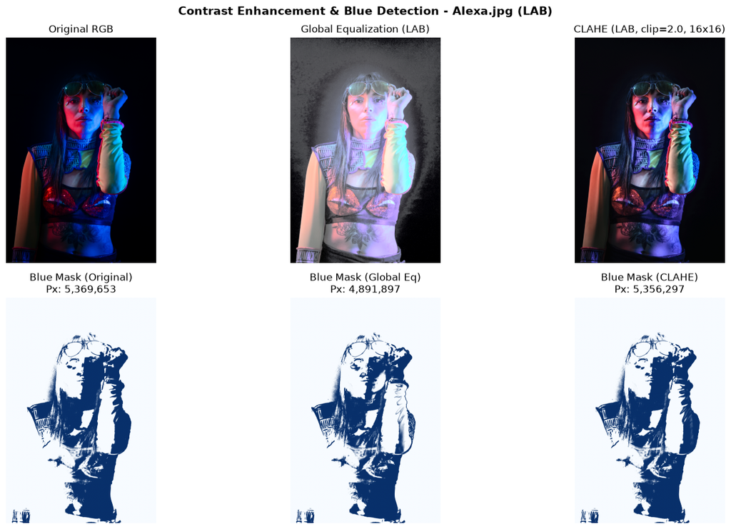

```
2026-09-08 19:59:16,326 - INFO - 🔎 Generating comparative panel for: Buenos_Aires.jpg (Space: LAB)
2026-09-08 19:59:29,953 - INFO - ✅ Figure saved to: D:\Personal\Maestria\05_Semestres\3er_Semestre\Vision_artificial\Scripts\Output\Script1\Perfil2_Practica1_GHEvsCLAHE__2026-09-08_19-58-12_Fig_Buenos_Aires_(LAB).png
```

[figure not shown]

```
2026-09-08 19:59:37,679 - INFO - 🔎 Generating comparative panel for: Piano_Man.jpg (Space: LAB)
2026-09-08 20:00:10,461 - INFO - ✅ Figure saved to: D:\Personal\Maestria\05_Semestres\3er_Semestre\Vision_artificial\Scripts\Output\Script1\Perfil2_Practica1_GHEvsCLAHE__2026-09-08_19-58-12_Fig_Piano_Man_(LAB).png
```

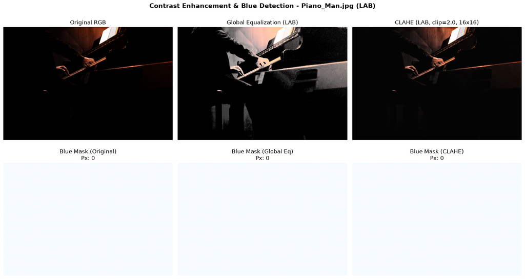

```
2026-09-08 20:00:29,751 - INFO - 🔎 Generating comparative panel for: Tatto_Studio.jpg (Space: LAB)
2026-09-08 20:01:00,612 - INFO - ✅ Figure saved to: D:\Personal\Maestria\05_Semestres\3er_Semestre\Vision_artificial\Scripts\Output\Script1\Perfil2_Practica1_GHEvsCLAHE__2026-09-08_19-58-12_Fig_Tatto_Studio_(LAB).png
```

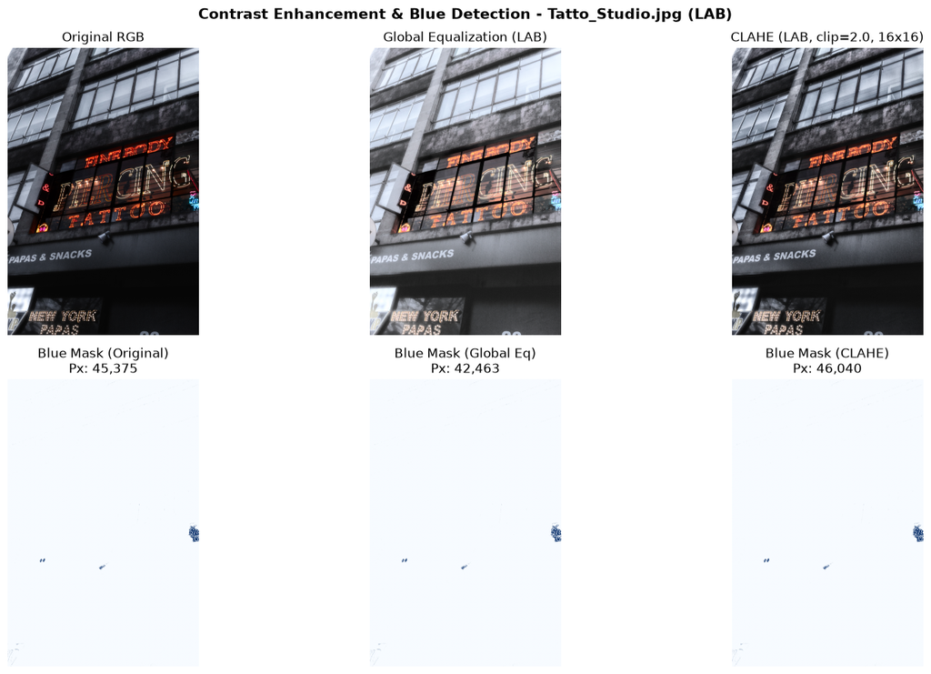

```
2026-09-08 20:01:19,112 - INFO - 🔎 Generating comparative panel for: Ushuaia.jpg (Space: LAB)
2026-09-08 20:01:49,634 - INFO - ✅ Figure saved to: D:\Personal\Maestria\05_Semestres\3er_Semestre\Vision_artificial\Scripts\Output\Script1\Perfil2_Practica1_GHEvsCLAHE__2026-09-08_19-58-12_Fig_Ushuaia_(LAB).png
```

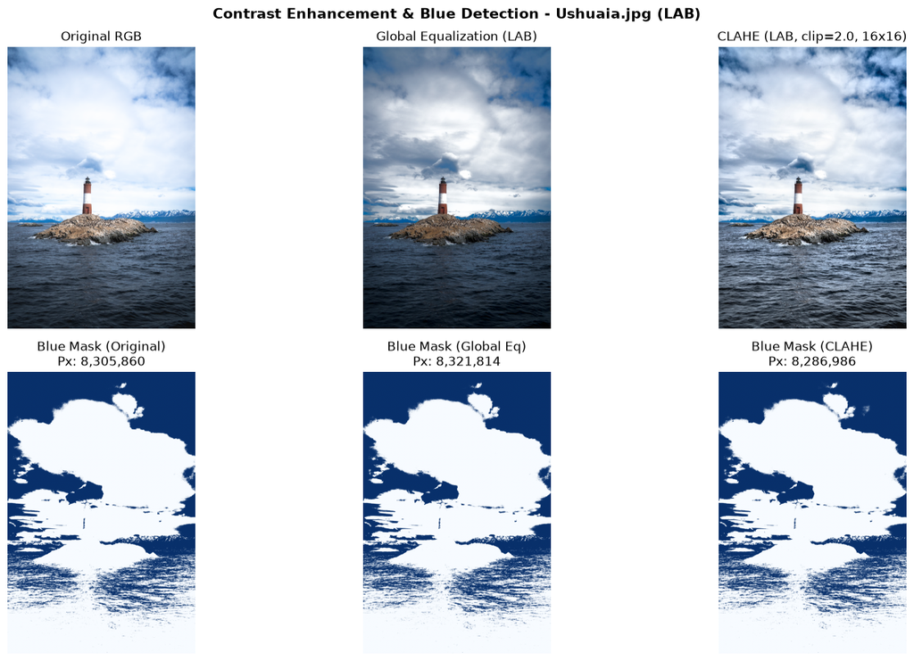

```
2026-09-08 20:02:07,681 - INFO - ------- SECTION 4 (END): Generate image comparison -------
```

```python
def display_and_save_comparison(dataset_list: list,space="LAB",sample_idx=0,clip_limit=2.0,tile_grid_size=(8, 8)):
    """
    Plots a 2x3 comparison panel (RGB images & Blue Masks) and optionally exports it.
    """
    if not dataset_list or sample_idx >= len(dataset_list):     # In case not images or index is greather than the total list
        logger.warning(f"⚠️ Cannot plot: sample_idx {sample_idx} is out of bounds.")
        return

    sample = dataset_list[sample_idx]
    orig_rgb = sample["rgb"]
    fname = sample["filename"]
    logger.info(f"🔎 Generating comparative panel for: {fname} (Space: {space})")

    try:
        # Process sample
        eq_rgb, _ = apply_global_equalization(orig_rgb, space=space)
        clahe_rgb, _ = apply_clahe(
            orig_rgb,
            space=space,
            clip_limit=clip_limit,
            tile_grid_size=tile_grid_size
        )

        # Blue masks
        mask_orig = find_blue_regions(orig_rgb, space=space)
        mask_eq = find_blue_regions(eq_rgb, space=space)
        mask_clahe = find_blue_regions(clahe_rgb, space=space)

        fig, axes = plt.subplots(2, 3, figsize=(16, 9))
        fig.suptitle(
            f"Contrast Enhancement & Blue Detection - {fname} ({space})",
            fontsize=14,
            fontweight="bold",
            y=0.98
        )

        # Row 1: RGB
        axes[0, 0].imshow(orig_rgb)
        axes[0, 0].set_title("Original RGB")
        axes[0, 1].imshow(eq_rgb)
        axes[0, 1].set_title(f"Global Equalization ({space})")
        axes[0, 2].imshow(clahe_rgb)
        axes[0, 2].set_title(f"CLAHE ({space}, clip={clip_limit}, {tile_grid_size[0]}x{tile_grid_size[1]})")

        # Row 2: Masks
        axes[1, 0].imshow(mask_orig, cmap="Blues")
        axes[1, 0].set_title(f"Blue Mask (Original)\nPx: {np.sum(mask_orig > 0):,}")
        axes[1, 1].imshow(mask_eq, cmap="Blues")
        axes[1, 1].set_title(f"Blue Mask (Global Eq)\nPx: {np.sum(mask_eq > 0):,}")
        axes[1, 2].imshow(mask_clahe, cmap="Blues")
        axes[1, 2].set_title(f"Blue Mask (CLAHE)\nPx: {np.sum(mask_clahe > 0):,}")

        for ax in axes.ravel():
            ax.axis("off")

        plt.tight_layout()

        # Export Figure if SAVE_IMAGES is enabled
        if SAVE_IMAGES:
            chart_name = f"{SCRIPT_PREFIX}__{DATE_STR}_Fig_{Path(fname).stem}_({space}).png"
            output_chart_path = str(output_dir / chart_name)
            plt.savefig(output_chart_path, dpi=300, bbox_inches="tight")
            logger.info(f"✅ Figure saved to: {output_chart_path}")
        plt.show()
        plt.close(fig)  # Free memory between iterations

    except Exception as e:
        logger.error(f"❌ Error during visualization: {trace.format_exc()}\n")
logger.info("------- SECTION 4: Generate image comparison -------")

#To delete previous images
if CLEAN_LOGS and output_dir.exists():
    for old_img in output_dir.glob(f"{SCRIPT_PREFIX}__*.png"):
        try:
            if old_img.is_file():
                old_img.unlink()
                logger.info(f"🗑️ Deleted: {old_img.name}")
        except Exception as e:
            logger.warning(f"⚠️ Could not delete {old_img.name}: {e}")

if dataset:
    # Select configuration
    COLOR_SPACE = "LAB"
    CLAHE_CFG=2
    for idx in range(len(dataset)):
        display_and_save_comparison(
            dataset_list=dataset,
            space=COLOR_SPACE,
            sample_idx=idx,
            clip_limit=CLAHE_CONFIGS[CLAHE_CFG]["clip_limit"] ,
            tile_grid_size=CLAHE_CONFIGS[CLAHE_CFG]["tile_grid_size"]
        )
logger.info("------- SECTION 4 (END): Generate image comparison -------")
```